# Anova

Xavier Bouteiller

March 27, 2020

# Needed packages

```r
library(ggplot2)
library(dplyr)
library(broom)
```

# Exercice 1 : rendement vigne

## Charger les données

```r
Vigne <-read.table(
          "./data/rendements_vigne.csv",
          sep = ";", dec = ".",
          header = TRUE)

head(Vigne)
str(Vigne)
```

````
```
##   Indiv Rendement Pesticide
## 1     1 0.6094503    Temoin
## 2     2 1.0308266    Temoin
## 3     3 1.1652521    Temoin
## 4     4 1.3025226    Temoin
## 5     5 1.1474522    Temoin
## 6     6 0.4024782    Temoin
```

```
## 'data.frame':    120 obs. of  3 variables:
##  $ Indiv    : int  1 2 3 4 5 6 7 8 9 10 ...
##  $ Rendement: num  0.609 1.031 1.165 1.303 1.147 ...
##  $ Pesticide: Factor w/ 4 levels "Bouillie","Pesticide_A",..: 4 4 4 4 4 4 4 4 4 4 ...
```
````

## Figures

[figure not shown]

```r
boxplot(Vigne[,2] ~ Vigne[,3])
boxplot(Vigne$Rendement ~ Vigne$Pesticide)
boxplot(Vigne[,"Rendement"] ~ Vigne[,"Pesticide"])
```

## Principes de l’ANOVA

```
##    Bouillie Pesticide_A Pesticide_B      Temoin
##   1.1354242   0.8188349   0.5816972   0.9570817
```

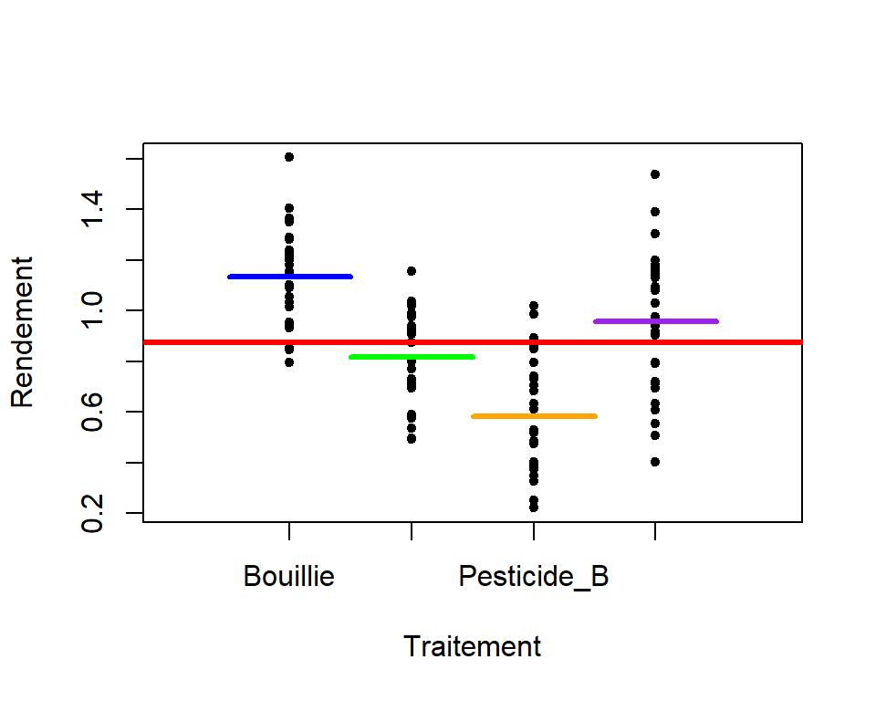

```r
                 stripchart(Vigne$Rendement ~ Vigne$Pesticide,
                            vertical = TRUE,
                            pch = 20,
                            xlim = c(0,5),
                            col = "black",
                            xlab = "Traitement",
                            ylab = "Rendement")
                 #moyenne générale
                 abline(h= mean(Vigne$Rendement),
                        col = "red",
                        lwd = 3)
                 #moyenne des groupes
                 tapply(Vigne$Rendement,
                        Vigne$Pesticide, mean)
                 segments(x0= c(0.5,1.5,2.5,3.5),
                          x1 = c(1.5,2.5,3.5, 4.5),
                          y0=tapply(Vigne$Rendement,
                                    Vigne$Pesticide, mean),
                          y1=tapply(Vigne$Rendement,
                                    Vigne$Pesticide, mean),
                          col = c("blue", "green", "orange", "purple"),
                                  lwd = 3)
```

## Démarche statistiques

1. Question bio
2. Hypothèses
3. Choix du test
4. Réalisation du test & validation
5. Conclusion

## 1. Question bio

Existe-t-il une différence significative de rendement moyen de la vigne selon les différents traitements?

## 2. Hypothèses

H0 : toutes les moyennes sont identiques

$$y_{ij} = \mu + \epsilon_{ij}$$

H1 : au moins une des moyennes testées est différentes significativement

$$y_{ij} = \mu + \alpha_{i} + \epsilon_{ij}$$

## 3. Choix du test

**ANOVA**: variable **quantitative** continue et var **qualitative** nominale (facteur) à 4 modalités

## 4. Réalisation du test & validation

### Realisation du modele

le modele lineaire peut être fait avec la fonction *aov()* ou *lm()*

```r
lm1 <- lm(Rendement ~ Pesticide,
          data = Vigne)
```

```r
lm1_bis <- aov(Rendement ~ Pesticide,
          data = Vigne)
```

Résultat identique, des différences dans la manipulation des objets créés

## validation et interpretation

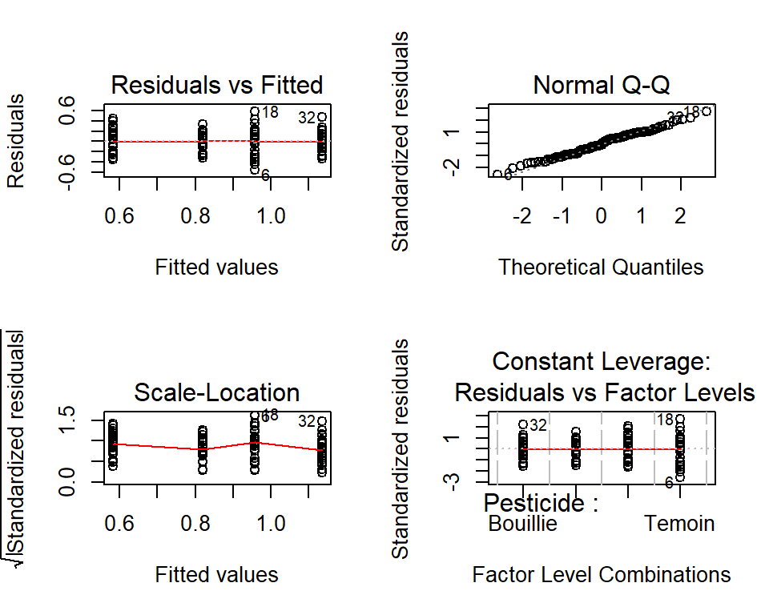

```r
par(mfrow=c(2,2))
plot(lm1)
```

Interpretation ssi le modèle est valide

```r
anova(lm1)
```

```
## Analysis of Variance Table
##
## Response: Rendement
##            Df Sum Sq Mean Sq F value    Pr(>F)
## Pesticide   3 4.9118  1.6373  34.109 7.025e-16 ***
## Residuals 116 5.5680  0.0480
## ---
## Signif. codes:  0 '***' 0.001 '**' 0.01 '*' 0.05 '.' 0.1 ' ' 1
```

## 5. Conclusion

- F=34.11
- p=7.03 $10^{-16}$ < 0.05

Il existe au moins une des moyennes différentes des autres  
(un au moins des $\alpha_{i}$ est différent de 0)

## 6. A quoi correspondent les coefficients estimés?

### Moyenne par groupe

```r
## Moyenne par traitement
knitr::kable(tapply(Vigne$Rendement,Vigne$Pesticide,mean))
```

|  | x |
| --- | --- |
| Bouillie | 1.1354242 |
| Pesticide_A | 0.8188349 |
| Pesticide_B | 0.5816972 |
| Temoin | 0.9570817 |

### Coefficients estimés : les $\alpha_{i}$

```r
## coefficients estimés les alpha_{i}
knitr::kable(coef(lm1))
```

|  | x |
| --- | --- |
| (Intercept) | 1.1354242 |
| PesticidePesticide_A | -0.3165893 |
| PesticidePesticide_B | -0.5537270 |
| PesticideTemoin | -0.1783425 |

## 7. Fitted values?

### fonction fitted()

```r
## chaque observation a comme fitted values la 'moyenne' de son groupe
knitr::kable(table(round(fitted(lm1),2)))
```

| Var1 | Freq |
| --- | --- |
| 0.58 | 30 |
| 0.82 | 30 |
| 0.96 | 30 |
| 1.14 | 30 |

### fonction residuals()

```r
## (fitted + residus) - valeur réelle
## les résidus correspondent bien à l'écart entre la fitted values et la valeur réelle
sum((fitted(lm1)+residuals(lm1)) - Vigne$Rendement)
```

```
## [1] -5.828671e-16
```

## Retrouvons manuellement le résultat du test

## Paramètres, ddl

```r
MuVigne <- mean(Vigne$Rendement) ; MuVigne
```

```
## [1] 0.8732595
```

```r
n <- nrow(Vigne) ; n
```

```
## [1] 120
```

```r
k <- nlevels(Vigne$Pesticide) ; k
```

```
## [1] 4
```

## Variance totale, expliquée et résiduelle

```r
# Variation totale (ici en rouge)
SCT <- sum((Vigne$Rendement - MuVigne)^2) ;
SCT
```

```
## [1] 10.47986
```

```r
# variation expliquée
MuPest<-tapply(Vigne$Rendement , Vigne$Pesticide, mean)
MuPest
```

```
##    Bouillie Pesticide_A Pesticide_B      Temoin
##   1.1354242   0.8188349   0.5816972   0.9570817
```

```r
SCE <- sum(table(Vigne$Pesticide)*(MuPest - MuVigne)^2)
SCE
```

```
## [1] 4.911813
```

```r
# Variation residuelle
SCI <- SCT - SCE ;
SCI
```

```
## [1] 5.568045
```

```r
anova(lm1)
```

```
## Analysis of Variance Table
##
## Response: Rendement
##            Df Sum Sq Mean Sq F value    Pr(>F)
## Pesticide   3 4.9118  1.6373  34.109 7.025e-16 ***
## Residuals 116 5.5680  0.0480
## ---
## Signif. codes:  0 '***' 0.001 '**' 0.01 '*' 0.05 '.' 0.1 ' ' 1
```

## Mean Square

```r
# Variation totale (ici en rouge)
MSCT <- SCT  / (n-1) ; MSCT
```

```
## [1] 0.08806603
```

```r
# variation expliquée
MSCE <- SCE / (k - 1) ; MSCE
```

```
## [1] 1.637271
```

```r
# Variation residuelle
MSCI <- SCI / (n -k) ; MSCI
```

```
## [1] 0.04800039
```

## F value

```r
Fcalc <- MSCE  / MSCI ; Fcalc
```

```
## [1] 34.10954
```

```r
Fcrit = qf(0.95,df1=k-1, df2=n-k)
Fcrit
```

```
## [1] 2.682809
```

Fcalc > Fcritique $\rightarrow$ p < 0.05

On rejette H0 …

## Test post Hoc

une fois qu’on a rejeté H0 et montré qu’au moins une des moyennes était différente, on peut faire un test post-Hoc

```r
# Ne fonctionne qu'avec un objet créée avec aov() et pas avec lm()
lm1_bis <- aov(Rendement ~ Pesticide, data = Vigne)
# le test post Hoc est réalisé avec la fonction TukeyHSD()
knitr::kable(TukeyHSD(lm1_bis)$Pesticide)
```

|  | diff | lwr | upr | p adj |
| --- | --- | --- | --- | --- |
| Pesticide_A-Bouillie | -0.3165893 | -0.4640451 | -0.1691334 | 0.0000009 |
| Pesticide_B-Bouillie | -0.5537270 | -0.7011828 | -0.4062712 | 0.0000000 |
| Temoin-Bouillie | -0.1783425 | -0.3257983 | -0.0308867 | 0.0109378 |
| Pesticide_B-Pesticide_A | -0.2371377 | -0.3845936 | -0.0896819 | 0.0003133 |
| Temoin-Pesticide_A | 0.1382467 | -0.0092091 | 0.2857026 | 0.0745947 |
| Temoin-Pesticide_B | 0.3753845 | 0.2279286 | 0.5228403 | 0.0000000 |

Le test post Hoc s’interpète comme un comparaison 2 à 2 des valeurs moyennes avec les hypothèses:

- H0: les 2 valeurs moyennes sont identiques
- H1: les 2 valeurs moyennes sont significativement différentes

Ici il existe une différence entre toutes les modalités sauf:

- Témoin - Pesticide A (p= 0.07 > 0.05)

# A vous de jouer

- Exercice 2 : DATA.csv

Existe-t-il une différence de taille moyenne pour au moins l’un des groupes ?

- Exercice 3 Diet.csv

Description du tableau dans Diet_data_description.docx

Quel régime est le meilleur pour perdre du poids ?

Existe-t-il une différence de perte de poids entre les deux sexes ?

- Exercice 4 : Tomato1.csv

Description du tableau Tomato_Rooting_data_description.docx Existe-t-il des différences de croissance entre la croissance moyenne des racines entre les 3 lignées M82, A et B